# Kaggle 데이터를 활용한 RSI 지표 예측

## 1. 분석 개요

주식 투자 방법론

- 기본적 분석: 재무 제표와 현금 흐름표, 손익계산서 등을 통해 회사의 내재적 가치를 평가하여 투자를 결정하는 정성적 분석
- 기술적 분석: 증권 시장에서의 가격 변동에 대한 움직임만을 분석하여 투자를 결정하는 정량적 분석. '거래량 지표, 시장 지표, 추세 지표, 탄력성 지표' 등의 기술적 지표를 활용함.

분석 목적

- 트레이더들은 기술적 지표들을 바탕으로 매수 매도 시점을 주관적으로 판단하곤 하는데, 머신러닝 기법을 활용하여 기술적 지표 중 하나인 RSI 값을 예측하여 미래의 매도 매수 시점을 결정하는데 도움을 주고자 함.

RSI(Relative Strength Index)

- 일정 기간 동안 주가가 전일 가격에 비해 상승한 변화량과 하락한 변화량의 평균갑
- 주기: 14일
- 0.7 이상이면 과매수 신호 -> 매도 포지션
- 0.3 이상이면 과매도 신호 -> 매수 포지션 (by J. Welles Wilder)

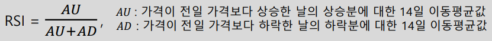

## 2. 데이터 전처리

```python
import pandas as pd
import numpy as np
import seaborn as sns
import matplotlib.pyplot as plt
import math
import xlrd   # pd.read_xlsx
import warnings
from sklearn.linear_model import LinearRegression
from sklearn.linear_model import Lasso
from sklearn.linear_model import Ridge
from sklearn.ensemble import GradientBoostingRegressor
from sklearn.ensemble import RandomForestRegressor
from sklearn.model_selection import train_test_split
import lightgbm as lgb
import optuna
from sklearn.preprocessing import MinMaxScaler
warnings.filterwarnings(action='ignore')
```

### 2-1. 데이터 불러오기

데이터 개요

```python
abd = pd.read_csv('C:/data/spanish_stocks/acs.csv')
abd
```

|  | Date | Close | High | Low | Open | Volume |
| --- | --- | --- | --- | --- | --- | --- |
| 0 | 2009-02-11 | 33.72 | 33.72 | 33.58 | 33.67 | 0 |
| 1 | 2009-02-12 | 33.10 | 33.72 | 33.10 | 33.65 | 0 |
| 2 | 2009-02-13 | 34.74 | 34.74 | 33.67 | 33.67 | 0 |
| 3 | 2009-02-16 | 33.51 | 34.56 | 33.51 | 34.31 | 0 |
| 4 | 2009-02-17 | 33.30 | 34.00 | 33.30 | 33.64 | 0 |
| ... | ... | ... | ... | ... | ... | ... |
| 2600 | 2019-06-03 | 36.77 | 36.77 | 36.18 | 36.72 | 545790 |
| 2601 | 2019-06-04 | 37.25 | 37.45 | 36.39 | 36.49 | 722980 |
| 2602 | 2019-06-05 | 37.40 | 37.77 | 37.23 | 37.45 | 1500000 |
| 2603 | 2019-06-06 | 37.19 | 37.82 | 37.05 | 37.58 | 633910 |
| 2604 | 2019-06-07 | 37.30 | 37.59 | 37.06 | 37.19 | 0 |

2605 rows × 6 columns

```python
abd.isnull().sum() #결측치 없음
```

```
Date      0
Close     0
High      0
Low       0
Open      0
Volume    0
dtype: int64
```

### 2-2. 외부 데이터 활용

1. 거시경제변수(연방기금금리, 환율)
2. 유가
3. OECD 경기선행지수

#### 연방기금금리

```python
# 금리 데이터 불러오기
# https://www.macrotrends.net/2015/fed-funds-rate-historical-chart
fedint = pd.read_csv('C:/data/fed-funds-rate-historical-chart.csv')
fedint.head()
```

|  | Date | value |
| --- | --- | --- |
| 0 | 1954-07-01 | 1.13 |
| 1 | 1954-07-02 | 1.25 |
| 2 | 1954-07-03 | 1.25 |
| 3 | 1954-07-04 | 1.25 |
| 4 | 1954-07-05 | 0.88 |

```python
# 금리 데이터 병합
abd2 = pd.merge(abd, fedint, how='left', left_on='Date', right_on='Date')
abd2.info()
```

```
<class 'pandas.core.frame.DataFrame'>
Int64Index: 2605 entries, 0 to 2604
Data columns (total 7 columns):
 #   Column  Non-Null Count  Dtype
---  ------  --------------  -----
 0   Date    2605 non-null   object
 1   Close   2605 non-null   float64
 2   High    2605 non-null   float64
 3   Low     2605 non-null   float64
 4   Open    2605 non-null   float64
 5   Volume  2605 non-null   int64
 6    value  2593 non-null   float64
dtypes: float64(5), int64(1), object(1)
memory usage: 162.8+ KB
```

```python
# 컬럼명 변경
abd2.rename(columns={' value': 'interest'}, inplace = True)
abd2.info()
```

```
<class 'pandas.core.frame.DataFrame'>
Int64Index: 2605 entries, 0 to 2604
Data columns (total 7 columns):
 #   Column    Non-Null Count  Dtype
---  ------    --------------  -----
 0   Date      2605 non-null   object
 1   Close     2605 non-null   float64
 2   High      2605 non-null   float64
 3   Low       2605 non-null   float64
 4   Open      2605 non-null   float64
 5   Volume    2605 non-null   int64
 6   interest  2593 non-null   float64
dtypes: float64(5), int64(1), object(1)
memory usage: 162.8+ KB
```

```python
# 금리 결측치 확인
# 결측치 개수: 12개
abd2.isnull().sum()
```

```
Date         0
Close        0
High         0
Low          0
Open         0
Volume       0
interest    12
dtype: int64
```

```python
# fed 금리 결측인 행 확인
abd2[abd2['interest'].isnull() == True]
```

|  | Date | Close | High | Low | Open | Volume | interest |
| --- | --- | --- | --- | --- | --- | --- | --- |
| 2215 | 2017-11-23 | 31.99 | 32.16 | 31.87 | 32.03 | 315020 | NaN |
| 2249 | 2018-01-15 | 32.34 | 32.55 | 32.21 | 32.53 | 716890 | NaN |
| 2274 | 2018-02-19 | 27.52 | 27.89 | 27.40 | 27.89 | 632660 | NaN |
| 2341 | 2018-05-28 | 34.56 | 34.95 | 34.53 | 34.65 | 744640 | NaN |
| 2368 | 2018-07-04 | 34.37 | 34.46 | 33.94 | 34.31 | 3130000 | NaN |
| 2411 | 2018-09-03 | 35.39 | 35.67 | 35.24 | 35.44 | 308550 | NaN |
| 2436 | 2018-10-08 | 35.40 | 36.00 | 35.37 | 35.41 | 378070 | NaN |
| 2461 | 2018-11-12 | 34.22 | 34.86 | 34.08 | 34.57 | 609320 | NaN |
| 2469 | 2018-11-22 | 32.87 | 33.29 | 32.83 | 33.03 | 579410 | NaN |
| 2508 | 2019-01-21 | 35.00 | 35.26 | 34.73 | 35.08 | 630040 | NaN |
| 2528 | 2019-02-18 | 37.55 | 37.55 | 37.13 | 37.24 | 571190 | NaN |
| 2595 | 2019-05-27 | 37.76 | 37.92 | 37.46 | 37.46 | 344820 | NaN |

#### Euro to Dollar 환율

```python
# 환율 데이터 불러오기
# https://www.federalreserve.gov/releases/h10/hist/default.htm
exchange = pd.read_csv('C:/data/FRB_H10.csv')
exchange.head()
```

|  | Time Period | exch |
| --- | --- | --- |
| 0 | 2009-02-11 | 1.2893 |
| 1 | 2009-02-12 | 1.2822 |
| 2 | 2009-02-13 | 1.2879 |
| 3 | 2009-02-16 | ND |
| 4 | 2009-02-17 | 1.2571 |

```python
# 환율 데이터 병합
abd2 = pd.merge(abd2, exchange, how='left', left_on='Date', right_on='Time Period')
abd2.info()
```

```
<class 'pandas.core.frame.DataFrame'>
Int64Index: 2605 entries, 0 to 2604
Data columns (total 9 columns):
 #   Column       Non-Null Count  Dtype
---  ------       --------------  -----
 0   Date         2605 non-null   object
 1   Close        2605 non-null   float64
 2   High         2605 non-null   float64
 3   Low          2605 non-null   float64
 4   Open         2605 non-null   float64
 5   Volume       2605 non-null   int64
 6   interest     2593 non-null   float64
 7   Time Period  2605 non-null   object
 8   exch         2605 non-null   object
dtypes: float64(5), int64(1), object(3)
memory usage: 203.5+ KB
```

```python
# Time Period 열 드롭
abd2.drop(['Time Period'], axis=1, inplace=True)
abd2.info()
```

```
<class 'pandas.core.frame.DataFrame'>
Int64Index: 2605 entries, 0 to 2604
Data columns (total 8 columns):
 #   Column    Non-Null Count  Dtype
---  ------    --------------  -----
 0   Date      2605 non-null   object
 1   Close     2605 non-null   float64
 2   High      2605 non-null   float64
 3   Low       2605 non-null   float64
 4   Open      2605 non-null   float64
 5   Volume    2605 non-null   int64
 6   interest  2593 non-null   float64
 7   exch      2605 non-null   object
dtypes: float64(5), int64(1), object(2)
memory usage: 183.2+ KB
```

```python
# 환율 'ND' -> 결측치 'NaN'으로 대체
abd2.exch[abd2['exch'] == 'ND'] = float('nan')
abd2
```

|  | Date | Close | High | Low | Open | Volume | interest | exch |
| --- | --- | --- | --- | --- | --- | --- | --- | --- |
| 0 | 2009-02-11 | 33.72 | 33.72 | 33.58 | 33.67 | 0 | 0.22 | 1.2893 |
| 1 | 2009-02-12 | 33.10 | 33.72 | 33.10 | 33.65 | 0 | 0.23 | 1.2822 |
| 2 | 2009-02-13 | 34.74 | 34.74 | 33.67 | 33.67 | 0 | 0.22 | 1.2879 |
| 3 | 2009-02-16 | 33.51 | 34.56 | 33.51 | 34.31 | 0 | 0.22 | NaN |
| 4 | 2009-02-17 | 33.30 | 34.00 | 33.30 | 33.64 | 0 | 0.25 | 1.2571 |
| ... | ... | ... | ... | ... | ... | ... | ... | ... |
| 2600 | 2019-06-03 | 36.77 | 36.77 | 36.18 | 36.72 | 545790 | 2.38 | 1.1206 |
| 2601 | 2019-06-04 | 37.25 | 37.45 | 36.39 | 36.49 | 722980 | 2.38 | 1.1236 |
| 2602 | 2019-06-05 | 37.40 | 37.77 | 37.23 | 37.45 | 1500000 | 2.38 | 1.1242 |
| 2603 | 2019-06-06 | 37.19 | 37.82 | 37.05 | 37.58 | 633910 | 2.37 | 1.1294 |
| 2604 | 2019-06-07 | 37.30 | 37.59 | 37.06 | 37.19 | 0 | 2.37 | 1.1324 |

2605 rows × 8 columns

```python
# exch 변수 object -> float 변경
abd2["exch"] = abd2.exch.astype(float)
abd2.info()
```

```
<class 'pandas.core.frame.DataFrame'>
Int64Index: 2605 entries, 0 to 2604
Data columns (total 8 columns):
 #   Column    Non-Null Count  Dtype
---  ------    --------------  -----
 0   Date      2605 non-null   object
 1   Close     2605 non-null   float64
 2   High      2605 non-null   float64
 3   Low       2605 non-null   float64
 4   Open      2605 non-null   float64
 5   Volume    2605 non-null   int64
 6   interest  2593 non-null   float64
 7   exch      2517 non-null   float64
dtypes: float64(6), int64(1), object(1)
memory usage: 183.2+ KB
```

```python
# 환율 데이터 결측치 확인
# 결측치 개수: 88개 (제거하기엔 너무 많음)
abd2.isnull().sum()
```

```
Date         0
Close        0
High         0
Low          0
Open         0
Volume       0
interest    12
exch        88
dtype: int64
```

- 결측치가 88개(약 4개월치)로 제거하기엔 너무 많음. 대체할 필요 있음.

#### 국제유가지수

```python
# 국제유가지수(WTI) 데이터
# http://www.itstat.go.kr/stat.it?no=1072&dateType=TMSRES_003&startYear=2009&startMonth=2&startDay=2&endYear=2019&endMonth=6&endDay=28&x=21&y=13
wti = pd.read_excel('C:/data/ITSTAT.xlsx')
wti.info()
```

```
<class 'pandas.core.frame.DataFrame'>
RangeIndex: 2556 entries, 0 to 2555
Data columns (total 4 columns):
 #   Column      Non-Null Count  Dtype
---  ------      --------------  -----
 0   Unnamed: 0  0 non-null      float64
 1   Unnamed: 1  0 non-null      float64
 2   Unnamed: 2  2554 non-null   object
 3   Unnamed: 3  2554 non-null   object
dtypes: float64(2), object(2)
memory usage: 80.0+ KB
```

```python
# 불필요한 컬럼 제거 / 컬럼명 변경
wti.drop(['Unnamed: 0','Unnamed: 1'], axis=1, inplace=True)
wti = wti.iloc[3:]
wti.rename(columns={'Unnamed: 2':'Date', 'Unnamed: 3':'WTI'}, inplace=True)
wti = wti.reset_index(drop=True) # 인덱스 리셋
wti.info()
```

```
<class 'pandas.core.frame.DataFrame'>
RangeIndex: 2553 entries, 0 to 2552
Data columns (total 2 columns):
 #   Column  Non-Null Count  Dtype
---  ------  --------------  -----
 0   Date    2553 non-null   object
 1   WTI     2553 non-null   object
dtypes: object(2)
memory usage: 40.0+ KB
```

```python
# Date에서 시간 버리기
wti['Date'] = pd.to_datetime(wti['Date'], format="%Y-%d-%m")
wti
```

|  | Date | WTI |
| --- | --- | --- |
| 0 | 2009-02-02 | 40.08 |
| 1 | 2009-02-03 | 40.78 |
| 2 | 2009-02-04 | 40.32 |
| 3 | 2009-02-05 | 41.17 |
| 4 | 2009-02-06 | 40.17 |
| ... | ... | ... |
| 2548 | 2019-06-24 | 57.90 |
| 2549 | 2019-06-25 | 57.83 |
| 2550 | 2019-06-26 | 59.38 |
| 2551 | 2019-06-27 | 59.43 |
| 2552 | 2019-06-28 | 58.47 |

2553 rows × 2 columns

```python
# wti의 Date 형식 datetime64[ns] => object로 변경
# 데이터프레임 abd2와의 병합을 위해 Data의 형식 맞춰줘야함.
wti.Date = wti.Date.astype(str)
```

```python
# WTI 데이터 병합
abd2 = pd.merge(abd2, wti, how='left', left_on='Date', right_on='Date')
abd2.info()
```

```
<class 'pandas.core.frame.DataFrame'>
Int64Index: 2605 entries, 0 to 2604
Data columns (total 9 columns):
 #   Column    Non-Null Count  Dtype
---  ------    --------------  -----
 0   Date      2605 non-null   object
 1   Close     2605 non-null   float64
 2   High      2605 non-null   float64
 3   Low       2605 non-null   float64
 4   Open      2605 non-null   float64
 5   Volume    2605 non-null   int64
 6   interest  2593 non-null   float64
 7   exch      2517 non-null   float64
 8   WTI       2469 non-null   object
dtypes: float64(6), int64(1), object(2)
memory usage: 203.5+ KB
```

```python
# WTI 컬럼 형식 object => float로 변경
abd2["WTI"] = abd2.WTI.astype(float)
abd2.info()
```

```
<class 'pandas.core.frame.DataFrame'>
Int64Index: 2605 entries, 0 to 2604
Data columns (total 9 columns):
 #   Column    Non-Null Count  Dtype
---  ------    --------------  -----
 0   Date      2605 non-null   object
 1   Close     2605 non-null   float64
 2   High      2605 non-null   float64
 3   Low       2605 non-null   float64
 4   Open      2605 non-null   float64
 5   Volume    2605 non-null   int64
 6   interest  2593 non-null   float64
 7   exch      2517 non-null   float64
 8   WTI       2469 non-null   float64
dtypes: float64(7), int64(1), object(1)
memory usage: 203.5+ KB
```

```python
# 결측치 개수 확인
abd2.isnull().sum()
```

```
Date          0
Close         0
High          0
Low           0
Open          0
Volume        0
interest     12
exch         88
WTI         136
dtype: int64
```

- 유가지수 또한 결측치가 136개(약 7개월치)로 제거하기엔 너무 많음. 대체할 필요 있음.

#### OECD 경기선행지수(CLI)

```python
# OECD 경기선행지수(CLI; composite leading indicator) 데이터 불러오기
# https://data.oecd.org/leadind/composite-leading-indicator-cli.htm
cli = pd.read_csv('C:/data/DP_LIVE_23112020061522848.csv')
cli.info()
```

```
<class 'pandas.core.frame.DataFrame'>
RangeIndex: 125 entries, 0 to 124
Data columns (total 2 columns):
 #   Column  Non-Null Count  Dtype
---  ------  --------------  -----
 0   Date    125 non-null    object
 1   CLI     125 non-null    float64
dtypes: float64(1), object(1)
memory usage: 2.1+ KB
```

```python
# 년도,월 추출 컬럼 생성
cli['Date2'] = cli['Date'].str[:-3]
abd2['Date2'] = abd2['Date'].str[:-3]
```

```python
# CLI와 abd2 병합
abd2 = pd.merge(abd2, cli, how='left', left_on='Date2', right_on='Date2')
abd2.drop(['Date2','Date_y'],axis=1,inplace=True)
abd2.rename(columns={'Date_x':'Date'}, inplace=True)
abd2.info()
```

```
<class 'pandas.core.frame.DataFrame'>
Int64Index: 2605 entries, 0 to 2604
Data columns (total 10 columns):
 #   Column    Non-Null Count  Dtype
---  ------    --------------  -----
 0   Date      2605 non-null   object
 1   Close     2605 non-null   float64
 2   High      2605 non-null   float64
 3   Low       2605 non-null   float64
 4   Open      2605 non-null   float64
 5   Volume    2605 non-null   int64
 6   interest  2593 non-null   float64
 7   exch      2517 non-null   float64
 8   WTI       2469 non-null   float64
 9   CLI       2605 non-null   float64
dtypes: float64(8), int64(1), object(1)
memory usage: 223.9+ KB
```

```python
# CLI 결측치 확인
abd2.isnull().sum()
```

```
Date          0
Close         0
High          0
Low           0
Open          0
Volume        0
interest     12
exch         88
WTI         136
CLI           0
dtype: int64
```

- CLI는 결측치 없음.
- interest, exch, WTI 결측치 대체 필요

### 2-3. 파생변수 생성 - 기술적 지표

[figure not shown]

#### 추세지표: SMA, EMA, MACD

```python
# SMA (종가)
def SMA(df, n1=20, n2=60, n3=120, n4=240):
    df['sma20'] = df['Close'].rolling(n1).mean()  # 4주
    #df['sma20'] = df['sma20'].where(df['sma20'].isnull() == False, df['Close'])

    #df['sma60'] = df['Close'].rolling(n2).mean()  # 분기
    #df['sma60'] = df['sma60'].where(df['sma60'].isnull() == False, df['Close'])

SMA(abd2)
```

```python
# EMA (종가)
def EMA(df, n1=20, n2=60, n3=120, n4=240):
    df['ema20'] = df['Close'].ewm(n1).mean()  # 4주
    #df['ema20'] = df['ema20'].where(df['ema20'].isnull() == False, df['Close'])

    #df['ema60'] = df['Close'].ewm(n2).mean()  # 분기
    #df['ema60'] = df['ema60'].where(df['ema60'].isnull() == False, df['Close'])

EMA(abd2)
```

```python
# MACD (종가)
def MACD(df, short=12, long=26, sign=9):
    df['macd'] = df['Close'].ewm(span=short).mean() - df['Close'].ewm(span=long).mean()
    #df['macd'] = df['macd'].where(df['macd'].isnull() == False, df['Close'])

MACD(abd2)
```

#### 변동성지표: ATR

```python
# ATR
def ATR(df, n=14):
    df['tr0'] = float('nan')
    df['tr1'] = float('nan')
    df['tr2'] = float('nan')
    for i in range(len(df)-2):
        df['tr0'].iloc[i+2] = abs(df['High'].iloc[i+1] - df['Low'].iloc[i+1])
        df['tr1'].iloc[i+2] = abs(df['High'].iloc[i+1] - df['Close'].iloc[i])
        df['tr2'].iloc[i+2] = abs(df['Low'].iloc[i+1] - df['Close'].iloc[i])

    tr = df[['tr0', 'tr1', 'tr2']].max(axis=1)
    df['atr'] = tr.rolling(n).mean()
    df.drop(['tr0','tr1','tr2'],axis=1,inplace=True)

ATR(abd2)
```

#### 모멘텀 지표: Momentum, CCI, Stochastic oscillator, RSI

```python
# Momentum (종가)
# 단, 금일이 아닌 1일전 종가 사용 / 기간 = 10일 사용
def MOM(df):
    df['mom'] = float('nan')
    for i in range(10,len(df)-1):
        df['mom'].iloc[i+1] = (df['Close'].iloc[i] / df['Close'].iloc[i-10]) * 100
        #df['mom'] = df['mom'].where(df['mom'].isnull() == False, df['Close'])

MOM(abd2)
```

```python
# CCI (종가, high, low)
# 금일이 아닌 1일전 종가 사용
def CCI(df, n=20):
    M = (df['High'] + df['Low'] + df['Close']) / 3
    Typical_price = M.rolling(n).sum()
    MA = Typical_price.rolling(n).mean()
    df['cci'] = (Typical_price - MA) / (0.015 * (abs(Typical_price - MA).rolling(n).mean()))
    #df['cci'] = df['cci'].where(df['cci'].isnull() == False, M)

CCI(abd2)
```

```python
# Stochastic OSC (종가, low, high)
# 금일이 아닌 1일전 종가 사용
# Fast %K = ((전날가 - n기간 중 최저가) / (n기간 중 최고가 - n기간 중 최저가)) * 100
def stochastic(df, n1=14, n2=5, n3=3):
    df['fast_k'] = float('nan')
    for i in range(14,len(df)-1):
        df['fast_k'].iloc[i+1] = ((df['Close'].iloc[i] - df['Low'].iloc[i-14:i].min()) / (df['High'].iloc[i-14:i].max() - df['Low'].iloc[i-14:i].min())) * 100
        #df['fast_k'] = df['fast_k'].where(df['fast_k'].isnull() == False, df['Close'])

        # Slow %K = Fast %K의 m기간 이동평균(SMA)
        df['slow_k'] = df['fast_k'].rolling(n2).mean()
        #df['slow_k'] = df['slow_k'].where(df['slow_k'].isnull() == False, df['Close'])

        # Slow %D = Slow %K의 t기간 이동평균(SMA)
        df['slow_d'] = df['slow_k'].rolling(n3).mean()
        #df['slow_d'] = df['slow_d'].where(df['slow_d'].isnull() == False, df['Close'])

stochastic(abd2)
```

```python
# RSI (종가)
def RSI(df, n=14):
    U = df['Close'].diff(1).where(df['Close'].diff(1) > 0, 0)
    D = df['Close'].diff(1).where(df['Close'].diff(1) < 0, 0) * (-1)
    AU = U.rolling(n).mean()
    AD = D.rolling(n).mean()
    df['rsi'] = AU / (AD+AU)
    # df['rsi'] = df['rsi'].where(df['rsi'].isnull() == False, df['Close'])

RSI(abd2)
```

```python
abd2.info()
```

```
<class 'pandas.core.frame.DataFrame'>
Int64Index: 2605 entries, 0 to 2604
Data columns (total 20 columns):
 #   Column    Non-Null Count  Dtype
---  ------    --------------  -----
 0   Date      2605 non-null   object
 1   Close     2605 non-null   float64
 2   High      2605 non-null   float64
 3   Low       2605 non-null   float64
 4   Open      2605 non-null   float64
 5   Volume    2605 non-null   int64
 6   interest  2593 non-null   float64
 7   exch      2517 non-null   float64
 8   WTI       2469 non-null   float64
 9   CLI       2605 non-null   float64
 10  sma20     2586 non-null   float64
 11  ema20     2605 non-null   float64
 12  macd      2605 non-null   float64
 13  atr       2590 non-null   float64
 14  mom       2594 non-null   float64
 15  cci       2548 non-null   float64
 16  fast_k    2590 non-null   float64
 17  slow_k    2586 non-null   float64
 18  slow_d    2584 non-null   float64
 19  rsi       2592 non-null   float64
dtypes: float64(18), int64(1), object(1)
memory usage: 427.4+ KB
```

### 2-4. 이상치 확인 및 제거

시가와 종가의 그래프를 통해 2009년 8월 26일 관측값에 오류가 있는 것을 확인하고 제거

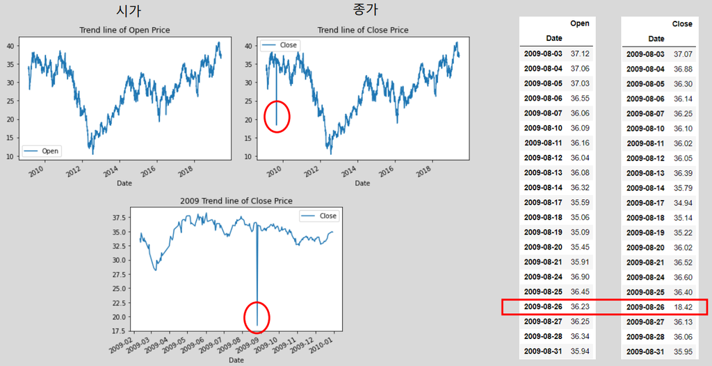

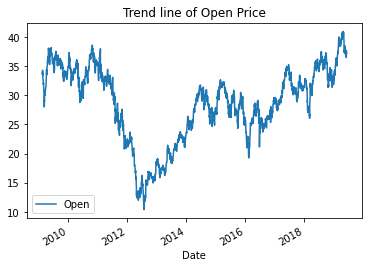

```python
# 이상치 확인 - 시가(Open)
new_abd2_o = abd2[['Date','Open']]
new_abd2_o['Date'] = pd.to_datetime(new_abd2_o['Date'])
new_abd2_o = new_abd2_o.set_index('Date')

plt.figure(figsize = (20,10))
new_abd2_o.plot(title = 'Trend line of Open Price')
```

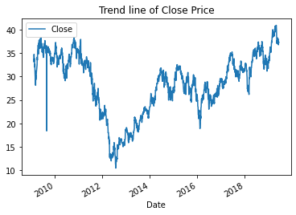

```python
# 이상치 확인 - 종가(Close)
new_abd2_c = abd2[['Date','Close']]
new_abd2_c['Date'] = pd.to_datetime(new_abd2_c['Date'])
new_abd2_c = new_abd2_c.set_index('Date')

plt.figure(figsize = (20,10))
new_abd2_c.plot(title = 'Trend line of Close Price')
```

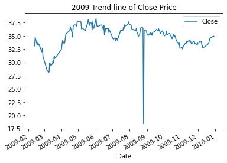

```python
# 이상치 확인 - 종가 2009년
new_abd2_c['2009'].plot(title = '2009 Trend line of Close Price')
```

```python
# 이상치 확인 - 종가 2009년 8월
new_abd2_c['2009-08']
```

| Date | Close |
| --- | --- |
| 2009-08-03 | 37.07 |
| 2009-08-04 | 36.88 |
| 2009-08-05 | 36.30 |
| 2009-08-06 | 36.14 |
| 2009-08-07 | 36.25 |
| 2009-08-10 | 36.10 |
| 2009-08-11 | 36.02 |
| 2009-08-12 | 36.05 |
| 2009-08-13 | 36.39 |
| 2009-08-14 | 35.79 |
| 2009-08-17 | 34.94 |
| 2009-08-18 | 35.14 |
| 2009-08-19 | 35.22 |
| 2009-08-20 | 36.02 |
| 2009-08-21 | 36.52 |
| 2009-08-24 | 36.60 |
| 2009-08-25 | 36.40 |
| 2009-08-26 | 18.42 |
| 2009-08-27 | 36.13 |
| 2009-08-28 | 36.06 |
| 2009-08-31 | 35.95 |

```python
# 이상치 확인 - 시가 2009년 8월
new_abd2_o['2009-08']
```

| Date | Open |
| --- | --- |
| 2009-08-03 | 37.12 |
| 2009-08-04 | 37.06 |
| 2009-08-05 | 37.03 |
| 2009-08-06 | 36.55 |
| 2009-08-07 | 36.06 |
| 2009-08-10 | 36.09 |
| 2009-08-11 | 36.16 |
| 2009-08-12 | 36.04 |
| 2009-08-13 | 36.08 |
| 2009-08-14 | 36.32 |
| 2009-08-17 | 35.59 |
| 2009-08-18 | 35.06 |
| 2009-08-19 | 35.09 |
| 2009-08-20 | 35.45 |
| 2009-08-21 | 35.91 |
| 2009-08-24 | 36.90 |
| 2009-08-25 | 36.45 |
| 2009-08-26 | 36.23 |
| 2009-08-27 | 36.25 |
| 2009-08-28 | 36.34 |
| 2009-08-31 | 35.94 |

```python
# 이상치 제거
abd2 = abd2[abd2['Date'] != '2009-08-26']
abd2[abd2['Date'] == '2009-08-26'] # 제거됨
```

|  | Date | Close | High | Low | Open | Volume | interest | exch | WTI | CLI | sma20 | ema20 | macd | atr | mom | cci | fast_k | slow_k | slow_d | rsi |
| --- | --- | --- | --- | --- | --- | --- | --- | --- | --- | --- | --- | --- | --- | --- | --- | --- | --- | --- | --- | --- |

### 2-5. 결측치 처리

- 금리(interest): 12개
- 환율(exch): 88개
- 유가(WTI): 136개
- 20일 SMA(sma20): 19개
- 모멘텀(mom): 11개
- Fast stochastic(fast_k): 15개
- K slow stochastic(slow_k): 19개
- D slow stochastic(slow_d): 21개
- CCI: 57개
- RSI: 13개
- ATR: 15개

```python
abd2.isnull().sum()
```

```
Date          0
Close         0
High          0
Low           0
Open          0
Volume        0
interest     12
exch         88
WTI         136
CLI           0
sma20        19
ema20         0
macd          0
atr          15
mom          11
cci          57
fast_k       15
slow_k       19
slow_d       21
rsi          13
dtype: int64
```

```python
# abd2 결측 제거
abd2 = abd2[abd2['exch'].isnull() == False]
abd2 = abd2[abd2['WTI'].isnull() == False]
abd2 = abd2[abd2['sma20'].isnull() == False]
abd2 = abd2[abd2['mom'].isnull() == False]
abd2 = abd2[abd2['fast_k'].isnull() == False]
abd2 = abd2[abd2['slow_k'].isnull() == False]
abd2 = abd2[abd2['slow_d'].isnull() == False]
abd2 = abd2[abd2['cci'].isnull() == False]
abd2 = abd2[abd2['atr'].isnull() == False]
abd2.info()
```

```
<class 'pandas.core.frame.DataFrame'>
Int64Index: 2384 entries, 57 to 2604
Data columns (total 20 columns):
 #   Column    Non-Null Count  Dtype
---  ------    --------------  -----
 0   Date      2384 non-null   object
 1   Close     2384 non-null   float64
 2   High      2384 non-null   float64
 3   Low       2384 non-null   float64
 4   Open      2384 non-null   float64
 5   Volume    2384 non-null   int64
 6   interest  2384 non-null   float64
 7   exch      2384 non-null   float64
 8   WTI       2384 non-null   float64
 9   CLI       2384 non-null   float64
 10  sma20     2384 non-null   float64
 11  ema20     2384 non-null   float64
 12  macd      2384 non-null   float64
 13  atr       2384 non-null   float64
 14  mom       2384 non-null   float64
 15  cci       2384 non-null   float64
 16  fast_k    2384 non-null   float64
 17  slow_k    2384 non-null   float64
 18  slow_d    2384 non-null   float64
 19  rsi       2384 non-null   float64
dtypes: float64(18), int64(1), object(1)
memory usage: 391.1+ KB
```

```python
abd2.isnull().sum()
```

```
Date        0
Close       0
High        0
Low         0
Open        0
Volume      0
interest    0
exch        0
WTI         0
CLI         0
sma20       0
ema20       0
macd        0
atr         0
mom         0
cci         0
fast_k      0
slow_k      0
slow_d      0
rsi         0
dtype: int64
```

## 2. 상관분석

경제 지표들, 그리고 기술적 지표들이 상관관계를 갖고 있을 것이라 판단하여 상관분석을 통해 상관관계가 높은 변수들을 제거하고자 함.

```python
# Date, high(최고가), low(최저가), open(시가), volume(거래량) 컬럼 제거
abd2.drop(['Close','High','Low','Open','Volume'], axis=1, inplace=True)
```

```python
corr = abd2.corr(method='pearson')
print(corr)
```

```
          interest      exch       WTI       CLI     sma20     ema20  \
interest  1.000000 -0.485537 -0.418246  0.387308  0.461648  0.455008
exch     -0.485537  1.000000  0.790492 -0.480184 -0.038177 -0.030585
WTI      -0.418246  0.790492  1.000000 -0.573133 -0.314280 -0.318764
CLI       0.387308 -0.480184 -0.573133  1.000000  0.651222  0.661109
sma20     0.461648 -0.038177 -0.314280  0.651222  1.000000  0.995175
ema20     0.455008 -0.030585 -0.318764  0.661109  0.995175  1.000000
macd      0.116089 -0.092988 -0.052404  0.020516  0.096279  0.027436
atr       0.053558  0.033164 -0.168347  0.083956  0.146554  0.175493
mom       0.024394 -0.044727 -0.037873 -0.016897 -0.053695 -0.061377
cci       0.037798 -0.057681 -0.005300 -0.015116  0.013401 -0.042406
fast_k    0.045571 -0.064870 -0.038179  0.029939 -0.026526 -0.036594
slow_k    0.057148 -0.076465 -0.045698  0.037172 -0.006553 -0.026468
slow_d    0.058585 -0.075261 -0.045133  0.037301  0.007001 -0.017842
rsi       0.043432 -0.046072 -0.028603  0.004996 -0.019617 -0.035811

              macd       atr       mom       cci    fast_k    slow_k  \
interest  0.116089  0.053558  0.024394  0.037798  0.045571  0.057148
exch     -0.092988  0.033164 -0.044727 -0.057681 -0.064870 -0.076465
WTI      -0.052404 -0.168347 -0.037873 -0.005300 -0.038179 -0.045698
CLI       0.020516  0.083956 -0.016897 -0.015116  0.029939  0.037172
sma20     0.096279  0.146554 -0.053695  0.013401 -0.026526 -0.006553
ema20     0.027436  0.175493 -0.061377 -0.042406 -0.036594 -0.026468
macd      1.000000 -0.271696  0.610936  0.799202  0.574777  0.760345
atr      -0.271696  1.000000 -0.060139 -0.273501 -0.097639 -0.196476
mom       0.610936 -0.060139  1.000000  0.396641  0.741550  0.751960
cci       0.799202 -0.273501  0.396641  1.000000  0.387678  0.585135
fast_k    0.574777 -0.097639  0.741550  0.387678  1.000000  0.775979
slow_k    0.760345 -0.196476  0.751960  0.585135  0.775979  1.000000
slow_d    0.789176 -0.224505  0.702666  0.644382  0.656950  0.970483
rsi       0.726688 -0.142461  0.727265  0.542467  0.737443  0.839756

            slow_d       rsi
interest  0.058585  0.043432
exch     -0.075261 -0.046072
WTI      -0.045133 -0.028603
CLI       0.037301  0.004996
sma20     0.007001 -0.019617
ema20    -0.017842 -0.035811
macd      0.789176  0.726688
atr      -0.224505 -0.142461
mom       0.702666  0.727265
cci       0.644382  0.542467
fast_k    0.656950  0.737443
slow_k    0.970483  0.839756
slow_d    1.000000  0.816773
rsi       0.816773  1.000000
```

#### 결과 해석

1. 이자율 - 환율, 유가, SMA, EMA 0.4~0.5 사이 / CLI 약 0.39
2. 환율 - 유가 약 0.8 / CLI -0.48
3. 유가 - CLI 약 -0.57
4. SMA - EMA 0.9 이상
5. MOM - MACD 0.61 / fast_k, slow_k, slow_d 0.7 이상 / rsi 0.72 / cci 약 0.39
6. MACD - fast_k 0.57 / slow_k, slow_d 0.7 이상 / cci 약 0.8 / rsi 약 0.7
7. 모멘텀 지표끼리 상관관계 높음
8. ATR은 모든 지표와 상관관계 낮음

#### 상관관계 높은 변수 제거하기

```python
abd2.drop(['WTI', 'ema20','mom','macd','fast_k','slow_k','slow_d','cci'], axis=1, inplace=True)
```

```python
abd2.info()
```

```
<class 'pandas.core.frame.DataFrame'>
Int64Index: 2384 entries, 57 to 2604
Data columns (total 7 columns):
 #   Column    Non-Null Count  Dtype
---  ------    --------------  -----
 0   Date      2384 non-null   object
 1   interest  2384 non-null   float64
 2   exch      2384 non-null   float64
 3   CLI       2384 non-null   float64
 4   sma20     2384 non-null   float64
 5   atr       2384 non-null   float64
 6   rsi       2384 non-null   float64
dtypes: float64(6), object(1)
memory usage: 149.0+ KB
```

#### 다시 상관분석

최종 입력 변수: interest, exch, CLI, SMA20, ATR

```python
corr = abd2.corr(method='pearson')
print(corr)
```

```
          interest      exch       CLI     sma20       atr       rsi
interest  1.000000 -0.485537  0.387308  0.461648  0.053558  0.043432
exch     -0.485537  1.000000 -0.480184 -0.038177  0.033164 -0.046072
CLI       0.387308 -0.480184  1.000000  0.651222  0.083956  0.004996
sma20     0.461648 -0.038177  0.651222  1.000000  0.146554 -0.019617
atr       0.053558  0.033164  0.083956  0.146554  1.000000 -0.142461
rsi       0.043432 -0.046072  0.004996 -0.019617 -0.142461  1.000000
```

## 3. 모델링 - RF / GB / LightGBM

성능 평가 지표: MAPE (Mean Absolute Percentage Error)

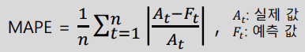

```python
# MAPE
def MAPE(y_true, y_pred):  # mean_absolute_percentage_error
    y_true, y_pred = np.array(y_true), np.array(y_pred)
    return round(np.mean(np.abs((y_true - y_pred) / y_true)) * 100 , 2)
```

```python
# input / target 컬럼 분리
X = abd2.drop(['rsi','Date'], axis=1)
y = abd2.rsi
```

### 3-1. Random Forest

```python
# train / test dataset 분리
X_train, X_test, y_train, y_test = train_test_split(X, y, test_size=0.25, random_state=100)
```

#### Hyperparameter tuning

```python
# Random Forest
def objective(trial):

    param = {'n_estimators' : trial.suggest_int('n_estimators', 50,500),
             'max_depth': trial.suggest_int( 'max_depth', 7, 25),
            }


    rf = RandomForestRegressor(**param, random_state=100)

    rf_model = rf.fit(X_train, y_train)
    preds = rf_model.predict(X_test)

    pred_labels = np.rint(preds)
    #accuracy = sklearn.metrics.accuracy_score(y_test, pred_labels)
    mape = MAPE(y_test, pred_labels)
    return mape
```

```python
# hyperparameter tuning: Optuna
study = optuna.create_study()
study.optimize(objective, n_trials = 100)
params = study.best_trial.params
print('Best trial:', params)
```

[output not shown]

[output cut: 75 more lines]

```
Best trial: {'n_estimators': 97, 'max_depth': 22}
```

```python
rf = RandomForestRegressor(**params, random_state=100)

rf_model = rf.fit(X_train, y_train)  # 모델 적합
y_pred = rf_model.predict(X_test)  # 타겟값 예측
MAPE(y_pred,y_test)
# 12.4
```

```
15.8
```

```python
# 변수 중요도
rf_feature_imp = rf_model.feature_importances_
rf_feature_imp = pd.DataFrame({'Value':rf_feature_imp,'Feature':X_train.columns})
rf_feature_imp_sort = rf_feature_imp.sort_values(by=['Value'], axis=0, ascending=False) # Value_per 내림차순 정렬
rf_feature_imp_sort
```

|  | Value | Feature |
| --- | --- | --- |
| 1 | 0.229298 | exch |
| 2 | 0.223390 | CLI |
| 3 | 0.218905 | sma20 |
| 4 | 0.207047 | atr |
| 0 | 0.121359 | interest |

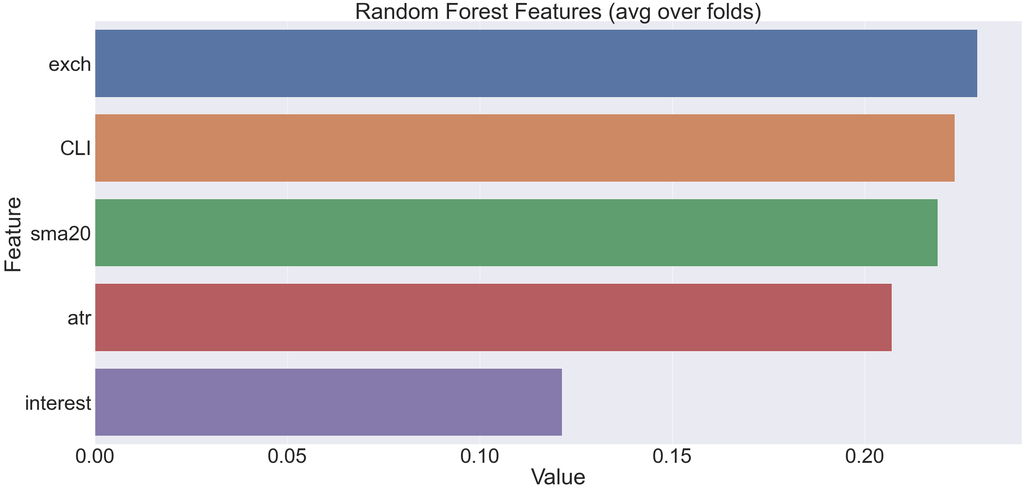

```python
# Feature Importance plot
plt.figure(figsize=(40, 20))
sns.set(font_scale = 5)
sns.barplot(x="Value", y="Feature", data=rf_feature_imp_sort)
plt.title('Random Forest Features (avg over folds)')
plt.tight_layout()
plt.show()
```

### 3-1. Gradient Boosting

```python
# train / test dataset 분리
X_train, X_test, y_train, y_test = train_test_split(X, y, test_size=0.25, random_state=100)
```

```python
# Gradient Boosting
def objective(trial):

    param = {'n_estimators' : trial.suggest_int('n_estimators', 50,500),
             'max_depth': trial.suggest_int( 'max_depth', 7, 25),
             #'min_samples_split': 5,
             'learning_rate': trial.suggest_uniform('learning_rate', 0.01, 1.0),
             #'loss': 'ls'
             }


    gb = GradientBoostingRegressor(**param, random_state=100)

    gb_model = gb.fit(X_train, y_train)
    preds = gb_model.predict(X_test)

    pred_labels = np.rint(preds)
    #accuracy = sklearn.metrics.accuracy_score(y_test, pred_labels)
    mape = MAPE(y_test, pred_labels)
    return mape
```

```python
# hyperparameter tuning: Optuna
study = optuna.create_study()
study.optimize(objective, n_trials = 100)
params = study.best_trial.params
print('Best trial:', params)
```

[output not shown]

[output cut: 75 more lines]

```
Best trial: {'n_estimators': 184, 'max_depth': 10, 'learning_rate': 0.24660930390038566}
```

```python
# 모델링
gb = GradientBoostingRegressor(**params, random_state=100)
gb_model = gb.fit(X_train, y_train)  # 모델 적합
y_pred = gb_model.predict(X_test)  # 모델 예측
MAPE(y_pred,y_test)
# 12.12
```

```
16.13
```

```python
# 변수 중요도
gb_feature_imp = gb_model.feature_importances_
gb_feature_imp = pd.DataFrame({'Value':gb_feature_imp,'Feature':X_train.columns})
gb_feature_imp_sort = gb_feature_imp.sort_values(by=['Value'], axis=0, ascending=False) # Value_per 내림차순 정렬
gb_feature_imp_sort
```

|  | Value | Feature |
| --- | --- | --- |
| 2 | 0.246059 | CLI |
| 3 | 0.234763 | sma20 |
| 1 | 0.228245 | exch |
| 4 | 0.186020 | atr |
| 0 | 0.104913 | interest |

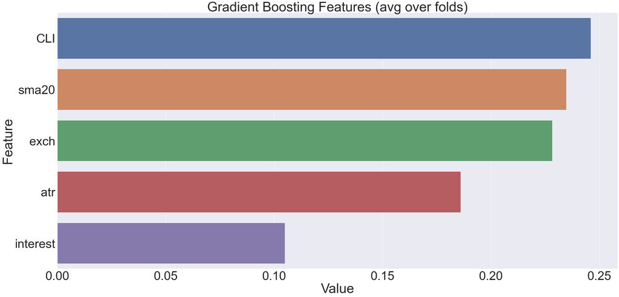

```python
# Feature Importance plot
plt.figure(figsize=(40, 20))
sns.set(font_scale = 5)
sns.barplot(x="Value", y="Feature", data=gb_feature_imp_sort)
plt.title('Gradient Boosting Features (avg over folds)')
plt.tight_layout()
plt.show()
```

### 3-1. LightGBM

```python
# LightGBM 학습용 데이터셋 제작
d_train = lgb.Dataset(X_train, label = y_train)
```

```python
# LigthGBM
def objective(trial):

    param = {
            'objective' : 'regression',
            'num_leaves': trial.suggest_int('num_leaves', 31, 256),
            #'max_depth' : trial.suggest_int( 'max_depth', 7, 25),
            'feature_fraction': trial.suggest_uniform('feature_fraction', 0.7, 1.0),
            'bagging_fraction': trial.suggest_uniform('bagging_fraction', 0.7, 1.0),
            'bagging_freq': trial.suggest_int('bagging_freq', 1, 7),
            'min_child_samples': trial.suggest_int('min_child_samples', 5, 100),
            'sub_sample' : trial.suggest_uniform('sub_sample',0.4,1.0),
            'boosting' : 'gbdt',
            'feature_pre_filter' : False
            #'n_estimators' : trial.suggest_int('n_estimators', 50,500)
            #'max_depth'
            }

    lgb_model = lgb.train(param, d_train,
                   valid_sets = [d_train])
    preds = lgb_model.predict(X_test)

    pred_labels = np.rint(preds)
    #accuracy = sklearn.metrics.accuracy_score(y_test, pred_labels)
    mape = MAPE(y_test, pred_labels)
    return mape
```

```python
# hyperparameter tuning: Optuna
study = optuna.create_study()
study.optimize(objective, n_trials = 100)
params = study.best_trial.params
print('Best trial:', study.best_trial.params)
```

```
[I 2021-01-19 19:12:05,481] A new study created in memory with name: no-name-ffeb5697-0648-4cce-b626-e3444ac271d8
```

[output not shown]

[output cut: 151 more lines]

[output not shown]

```
[I 2021-01-19 19:12:05,898] Trial 0 finished with value: 87.66 and parameters: {'num_leaves': 71, 'feature_fraction': 0.8975643264878599, 'bagging_fraction': 0.9099466453552683, 'bagging_freq': 5, 'min_child_samples': 66, 'sub_sample': 0.7850579661770093}. Best is trial 0 with value: 87.66.
```

[output not shown]

[output cut: 52 more lines]

[output not shown]

```
[I 2021-01-19 19:12:06,219] Trial 1 finished with value: 87.59 and parameters: {'num_leaves': 186, 'feature_fraction': 0.705135886607138, 'bagging_fraction': 0.9665820411079921, 'bagging_freq': 7, 'min_child_samples': 74, 'sub_sample': 0.5314017067389017}. Best is trial 1 with value: 87.59.
```

[output not shown]

[output cut: 194 more lines]

[output not shown]

```
[I 2021-01-19 19:12:06,535] Trial 2 finished with value: 88.73 and parameters: {'num_leaves': 144, 'feature_fraction': 0.7479980504886868, 'bagging_fraction': 0.8782968198281437, 'bagging_freq': 5, 'min_child_samples': 70, 'sub_sample': 0.9567840012388427}. Best is trial 1 with value: 87.59.
```

[output not shown]

[output cut: 190 more lines]

[output not shown]

```
[I 2021-01-19 19:12:06,866] Trial 3 finished with value: 88.47 and parameters: {'num_leaves': 155, 'feature_fraction': 0.7966559130728643, 'bagging_fraction': 0.9427135629081429, 'bagging_freq': 6, 'min_child_samples': 74, 'sub_sample': 0.8193064758311086}. Best is trial 1 with value: 87.59.
```

[output not shown]

[output cut: 165 more lines]

[output not shown]

```
[I 2021-01-19 19:12:07,222] Trial 4 finished with value: 89.29 and parameters: {'num_leaves': 157, 'feature_fraction': 0.7282392685750645, 'bagging_fraction': 0.8874289629651594, 'bagging_freq': 6, 'min_child_samples': 67, 'sub_sample': 0.850115098824958}. Best is trial 1 with value: 87.59.
```

[output not shown]

[output cut: 61 more lines]

[output not shown]

```
[I 2021-01-19 19:12:07,529] Trial 5 finished with value: 91.55 and parameters: {'num_leaves': 161, 'feature_fraction': 0.8841025129849264, 'bagging_fraction': 0.9282802449055378, 'bagging_freq': 6, 'min_child_samples': 83, 'sub_sample': 0.5728568262380703}. Best is trial 1 with value: 87.59.
```

[output not shown]

[output cut: 200 more lines]

[output not shown]

```
[I 2021-01-19 19:12:07,841] Trial 6 finished with value: 90.03 and parameters: {'num_leaves': 152, 'feature_fraction': 0.8136236520661446, 'bagging_fraction': 0.7746634488275702, 'bagging_freq': 5, 'min_child_samples': 66, 'sub_sample': 0.8171007771440046}. Best is trial 1 with value: 87.59.
```

[output not shown]

[output cut: 211 more lines]

[output not shown]

```
[I 2021-01-19 19:12:08,372] Trial 7 finished with value: 84.41 and parameters: {'num_leaves': 179, 'feature_fraction': 0.7736098699152284, 'bagging_fraction': 0.8325610425767518, 'bagging_freq': 7, 'min_child_samples': 18, 'sub_sample': 0.9591380519284749}. Best is trial 7 with value: 84.41.
```

[output not shown]

[output cut: 157 more lines]

[output not shown]

```
[I 2021-01-19 19:12:08,671] Trial 8 finished with value: 91.39 and parameters: {'num_leaves': 92, 'feature_fraction': 0.9376889683332452, 'bagging_fraction': 0.9308639902168041, 'bagging_freq': 1, 'min_child_samples': 85, 'sub_sample': 0.7658452408548919}. Best is trial 7 with value: 84.41.
```

[output not shown]

[output cut: 75 more lines]

[output not shown]

```
[I 2021-01-19 19:12:08,996] Trial 9 finished with value: 88.37 and parameters: {'num_leaves': 39, 'feature_fraction': 0.7921237313729382, 'bagging_fraction': 0.9881063216683338, 'bagging_freq': 2, 'min_child_samples': 69, 'sub_sample': 0.5504979610261123}. Best is trial 7 with value: 84.41.
```

[output not shown]

[output cut: 230 more lines]

[output not shown]

```
[I 2021-01-19 19:12:09,706] Trial 10 finished with value: 82.9 and parameters: {'num_leaves': 225, 'feature_fraction': 0.9960441538836537, 'bagging_fraction': 0.7836135930892673, 'bagging_freq': 3, 'min_child_samples': 11, 'sub_sample': 0.9949548174908015}. Best is trial 10 with value: 82.9.
```

[output not shown]

[output cut: 152 more lines]

[output not shown]

```
[I 2021-01-19 19:12:10,460] Trial 11 finished with value: 83.66 and parameters: {'num_leaves': 235, 'feature_fraction': 0.9918131392116506, 'bagging_fraction': 0.7885189475968728, 'bagging_freq': 3, 'min_child_samples': 11, 'sub_sample': 0.9975546364617279}. Best is trial 10 with value: 82.9.
```

[output not shown]

[output cut: 157 more lines]

[output not shown]

```
[I 2021-01-19 19:12:11,568] Trial 12 finished with value: 84.85 and parameters: {'num_leaves': 255, 'feature_fraction': 0.9929913598333147, 'bagging_fraction': 0.709531468027763, 'bagging_freq': 3, 'min_child_samples': 6, 'sub_sample': 0.9814738459663914}. Best is trial 10 with value: 82.9.
```

[output not shown]

[output cut: 153 more lines]

[output not shown]

```
[I 2021-01-19 19:12:12,014] Trial 13 finished with value: 85.42 and parameters: {'num_leaves': 255, 'feature_fraction': 0.9972346092774831, 'bagging_fraction': 0.782788340220281, 'bagging_freq': 3, 'min_child_samples': 34, 'sub_sample': 0.9975024463349539}. Best is trial 10 with value: 82.9.
```

[output not shown]

[output cut: 153 more lines]

[output not shown]

```
[I 2021-01-19 19:12:12,443] Trial 14 finished with value: 86.33 and parameters: {'num_leaves': 220, 'feature_fraction': 0.95886023439123, 'bagging_fraction': 0.7146203946360412, 'bagging_freq': 3, 'min_child_samples': 35, 'sub_sample': 0.40034073916253693}. Best is trial 10 with value: 82.9.
```

[output not shown]

[output cut: 70 more lines]

[output not shown]

```
[I 2021-01-19 19:12:13,651] Trial 15 finished with value: 83.17 and parameters: {'num_leaves': 221, 'feature_fraction': 0.9481409931321999, 'bagging_fraction': 0.7789615419229983, 'bagging_freq': 1, 'min_child_samples': 5, 'sub_sample': 0.8930063648057149}. Best is trial 10 with value: 82.9.
```

[output not shown]

[output cut: 153 more lines]

[output not shown]

```
[I 2021-01-19 19:12:14,129] Trial 16 finished with value: 84.39 and parameters: {'num_leaves': 209, 'feature_fraction': 0.940215925765437, 'bagging_fraction': 0.7454880943419101, 'bagging_freq': 1, 'min_child_samples': 27, 'sub_sample': 0.8927592143695843}. Best is trial 10 with value: 82.9.
```

[output not shown]

[output cut: 106 more lines]

[output not shown]

```
[I 2021-01-19 19:12:14,566] Trial 17 finished with value: 87.78 and parameters: {'num_leaves': 106, 'feature_fraction': 0.8900639377775372, 'bagging_fraction': 0.8186492936745038, 'bagging_freq': 2, 'min_child_samples': 46, 'sub_sample': 0.6758194851842794}. Best is trial 10 with value: 82.9.
```

[output not shown]

[output cut: 145 more lines]

[output not shown]

```
[I 2021-01-19 19:12:14,921] Trial 18 finished with value: 91.88 and parameters: {'num_leaves': 195, 'feature_fraction': 0.8428365746778272, 'bagging_fraction': 0.7441784608073505, 'bagging_freq': 2, 'min_child_samples': 98, 'sub_sample': 0.9042760986086219}. Best is trial 10 with value: 82.9.
```

[output not shown]

[output cut: 173 more lines]

[output not shown]

```
[I 2021-01-19 19:12:15,535] Trial 19 finished with value: 84.68 and parameters: {'num_leaves': 231, 'feature_fraction': 0.9550035673497305, 'bagging_fraction': 0.8146689378723024, 'bagging_freq': 4, 'min_child_samples': 16, 'sub_sample': 0.660378954144349}. Best is trial 10 with value: 82.9.
```

[output not shown]

[output cut: 108 more lines]

[output not shown]

```
[I 2021-01-19 19:12:15,936] Trial 20 finished with value: 86.72 and parameters: {'num_leaves': 121, 'feature_fraction': 0.916210002835733, 'bagging_fraction': 0.8579003741101563, 'bagging_freq': 1, 'min_child_samples': 49, 'sub_sample': 0.9108257856745497}. Best is trial 10 with value: 82.9.
```

[output not shown]

[output cut: 229 more lines]

[output not shown]

```
[I 2021-01-19 19:12:16,909] Trial 21 finished with value: 83.09 and parameters: {'num_leaves': 240, 'feature_fraction': 0.9878483783454083, 'bagging_fraction': 0.7920854528005755, 'bagging_freq': 4, 'min_child_samples': 8, 'sub_sample': 0.9956646262456879}. Best is trial 10 with value: 82.9.
```

[output not shown]

[output cut: 160 more lines]

[output not shown]

```
[I 2021-01-19 19:12:18,170] Trial 22 finished with value: 82.85 and parameters: {'num_leaves': 245, 'feature_fraction': 0.9728543406528535, 'bagging_fraction': 0.7623719115472173, 'bagging_freq': 4, 'min_child_samples': 6, 'sub_sample': 0.9128697337058209}. Best is trial 22 with value: 82.85.
```

[output not shown]

[output cut: 136 more lines]

[output not shown]

```
[I 2021-01-19 19:12:18,671] Trial 23 finished with value: 84.95 and parameters: {'num_leaves': 250, 'feature_fraction': 0.9766919350644325, 'bagging_fraction': 0.7560873924649805, 'bagging_freq': 4, 'min_child_samples': 23, 'sub_sample': 0.9434857219259042}. Best is trial 22 with value: 82.85.
```

[output not shown]

[output cut: 171 more lines]

[output not shown]

```
[I 2021-01-19 19:12:20,073] Trial 24 finished with value: 83.15 and parameters: {'num_leaves': 245, 'feature_fraction': 0.9753342222108841, 'bagging_fraction': 0.8082194088877024, 'bagging_freq': 4, 'min_child_samples': 5, 'sub_sample': 0.996600346638383}. Best is trial 22 with value: 82.85.
```

[output not shown]

[output cut: 150 more lines]

[output not shown]

```
[I 2021-01-19 19:12:20,781] Trial 25 finished with value: 83.69 and parameters: {'num_leaves': 206, 'feature_fraction': 0.9191021873123872, 'bagging_fraction': 0.7286416651648994, 'bagging_freq': 4, 'min_child_samples': 12, 'sub_sample': 0.7158982938962626}. Best is trial 22 with value: 82.85.
```

[output not shown]

[output cut: 156 more lines]

[output not shown]

```
[I 2021-01-19 19:12:21,252] Trial 26 finished with value: 84.62 and parameters: {'num_leaves': 234, 'feature_fraction': 0.9957462105616397, 'bagging_fraction': 0.844901792197634, 'bagging_freq': 5, 'min_child_samples': 30, 'sub_sample': 0.8566094235494818}. Best is trial 22 with value: 82.85.
```

[output not shown]

[output cut: 153 more lines]

[output not shown]

```
[I 2021-01-19 19:12:21,702] Trial 27 finished with value: 87.11 and parameters: {'num_leaves': 256, 'feature_fraction': 0.8597246960710507, 'bagging_fraction': 0.7997241425215568, 'bagging_freq': 3, 'min_child_samples': 40, 'sub_sample': 0.9439931219810626}. Best is trial 22 with value: 82.85.
```

[output not shown]

[output cut: 92 more lines]

[output not shown]

```
[I 2021-01-19 19:12:22,299] Trial 28 finished with value: 84.57 and parameters: {'num_leaves': 178, 'feature_fraction': 0.973891718769434, 'bagging_fraction': 0.7669922130406408, 'bagging_freq': 4, 'min_child_samples': 21, 'sub_sample': 0.9974751276992004}. Best is trial 22 with value: 82.85.
```

[output not shown]

[output cut: 122 more lines]

[output not shown]

```
[I 2021-01-19 19:12:22,706] Trial 29 finished with value: 88.18 and parameters: {'num_leaves': 208, 'feature_fraction': 0.9159926024767305, 'bagging_fraction': 0.7310851749674515, 'bagging_freq': 2, 'min_child_samples': 57, 'sub_sample': 0.7632137509194932}. Best is trial 22 with value: 82.85.
```

[output not shown]

[output cut: 123 more lines]

[output not shown]

```
[I 2021-01-19 19:12:23,038] Trial 30 finished with value: 86.91 and parameters: {'num_leaves': 33, 'feature_fraction': 0.9648569599313569, 'bagging_fraction': 0.7028805792217516, 'bagging_freq': 5, 'min_child_samples': 10, 'sub_sample': 0.4073612219547658}. Best is trial 22 with value: 82.85.
```

[output not shown]

[output cut: 172 more lines]

[output not shown]

```
[I 2021-01-19 19:12:24,438] Trial 31 finished with value: 83.1 and parameters: {'num_leaves': 241, 'feature_fraction': 0.9788740484005042, 'bagging_fraction': 0.8049348597189837, 'bagging_freq': 4, 'min_child_samples': 5, 'sub_sample': 0.996239962616622}. Best is trial 22 with value: 82.85.
```

[output not shown]

[output cut: 114 more lines]

[output not shown]

```
[I 2021-01-19 19:12:25,818] Trial 32 finished with value: 84.16 and parameters: {'num_leaves': 241, 'feature_fraction': 0.9951441292809754, 'bagging_fraction': 0.8276437442662965, 'bagging_freq': 3, 'min_child_samples': 5, 'sub_sample': 0.9289991991888782}. Best is trial 22 with value: 82.85.
```

[output not shown]

[output cut: 153 more lines]

[output not shown]

```
[I 2021-01-19 19:12:26,490] Trial 33 finished with value: 84.75 and parameters: {'num_leaves': 219, 'feature_fraction': 0.9298327363548138, 'bagging_fraction': 0.7925842669658455, 'bagging_freq': 4, 'min_child_samples': 16, 'sub_sample': 0.9720416343466604}. Best is trial 22 with value: 82.85.
```

[output not shown]

[output cut: 126 more lines]

[output not shown]

```
[I 2021-01-19 19:12:27,267] Trial 34 finished with value: 83.07 and parameters: {'num_leaves': 195, 'feature_fraction': 0.9746207329782346, 'bagging_fraction': 0.7617496168070905, 'bagging_freq': 5, 'min_child_samples': 11, 'sub_sample': 0.8724902042489704}. Best is trial 22 with value: 82.85.
```

[output not shown]

[output cut: 158 more lines]

[output not shown]

```
[I 2021-01-19 19:12:27,790] Trial 35 finished with value: 84.41 and parameters: {'num_leaves': 191, 'feature_fraction': 0.9554910688313247, 'bagging_fraction': 0.7591860971137342, 'bagging_freq': 5, 'min_child_samples': 25, 'sub_sample': 0.8526186431918257}. Best is trial 22 with value: 82.85.
```

[output not shown]

[output cut: 171 more lines]

[output not shown]

```
[I 2021-01-19 19:12:28,606] Trial 36 finished with value: 82.66 and parameters: {'num_leaves': 167, 'feature_fraction': 0.9020194898559679, 'bagging_fraction': 0.732175229910716, 'bagging_freq': 6, 'min_child_samples': 10, 'sub_sample': 0.8212768866067778}. Best is trial 36 with value: 82.66.
```

[output not shown]

[output cut: 156 more lines]

[output not shown]

```
[I 2021-01-19 19:12:29,307] Trial 37 finished with value: 83.89 and parameters: {'num_leaves': 171, 'feature_fraction': 0.8733049321568498, 'bagging_fraction': 0.7338084112925222, 'bagging_freq': 6, 'min_child_samples': 14, 'sub_sample': 0.8153986588501894}. Best is trial 36 with value: 82.66.
```

[output not shown]

[output cut: 138 more lines]

[output not shown]

```
[I 2021-01-19 19:12:29,916] Trial 38 finished with value: 84.53 and parameters: {'num_leaves': 164, 'feature_fraction': 0.9072240127648177, 'bagging_fraction': 0.7206454301566079, 'bagging_freq': 7, 'min_child_samples': 20, 'sub_sample': 0.8671124753114361}. Best is trial 36 with value: 82.66.
```

[output not shown]

[output cut: 162 more lines]

[output not shown]